# Lab 10

Matt Crump

11/3/2020

1. Your task is to obtain the data from the following paper and conduct a reproducible analysis of their results.

Rosenbaum, D., Mama, Y., & Algom, D. (2017). Stand by Your Stroop: Standing Up Enhances Selective Attention and Cognitive Control. Psychological science, 28(12), 1864-1867.

Note, the paper, the data, and an existing reproducible analysis of this data is available at https://crumplab.github.io/statisticsLab/lab-10-factorial-anova.html#important-stuff-4

The re-analysis should focus only on Experiment 3. There are three main goals

1. Reproduce as much of the analysis as possible using only paired-sample t-tests. Note, the authors reported a 2x2 repeated measures ANOVA, but consider how the same questions could be answered by t-tests (2 points)
2. Reproduce a graph of the means, like shown in the paper (2 points)
3. Present a power-curve analysis for the design. (2 points)

```r
library(papaja)
library(dplyr)
library(ggplot2)

# load data

all_data <- read.csv("open_data/stroop_stand.csv")

# Stand Stroop effect

(stand_stroop <- t.test(all_data$incongruent_stand,
       all_data$congruent_stand,
       paired = TRUE))
```

```
##
##  Paired t-test
##
## data:  all_data$incongruent_stand and all_data$congruent_stand
## t = 14.327, df = 49, p-value < 2.2e-16
## alternative hypothesis: true difference in means is not equal to 0
## 95 percent confidence interval:
##   82.49462 109.41185
## sample estimates:
## mean of the differences
##                95.95323
```

```r
# Sit Stroop effect

(sit_stroop <- t.test(all_data$incongruent_sit,
       all_data$congruent_sit,
       paired = TRUE))
```

```
##
##  Paired t-test
##
## data:  all_data$incongruent_sit and all_data$congruent_sit
## t = 16.516, df = 49, p-value < 2.2e-16
## alternative hypothesis: true difference in means is not equal to 0
## 95 percent confidence interval:
##  104.3997 133.3250
## sample estimates:
## mean of the differences
##                118.8623
```

The authors wrote:

The Stroop effects in both the sitting condition, M = 118.9 ms, t(49) = 16.52, p < .01, d = 2.376, and the standing condition, M = 95.9 ms, t(49) = 14.327, p < .01, d = 2.034, were highly reliable…

Our reproduction of the analysis found:

The Stroop effects in both the sitting condition, $M_d = 118.86$, 95% CI $[104.40$, $133.33]$, $t(49) = 16.52$, $p < .001$, and the standing condition, $M_d = 95.95$, 95% CI $[82.49$, $109.41]$, $t(49) = 14.33$, $p < .001$, were highly reliable…

## Advanced

The major finding in the paper was that the size of the Stroop “shrunk” when people were standing compared to sitting. The above analyses did not address this question, they only showed that the Stroop effect (slower RTs for incongruent than congruent) appeared to be significant in both sitting and standing conditions. According to the means, it looked like the overall effect was larger when people were sitting (118.9) compared to standing (95.9).

Although the authors used a repeated measures ANOVA to provide statistical evidence that the Stroop effect was smaller in the stand than sit condition, they could have used a paired samples t-test, which boils down to a one-sample t-test on the relevant difference scores.

For example:

```r
stand_stroop_scores <- all_data$incongruent_stand-all_data$congruent_stand
sit_stroop_scores <- all_data$incongruent_sit-all_data$congruent_sit

stroop_differences <- sit_stroop_scores - stand_stroop_scores

(paired_results <- t.test(stand_stroop_scores,
                         sit_stroop_scores,
                         paired=TRUE))
```

```
##
##  Paired t-test
##
## data:  stand_stroop_scores and sit_stroop_scores
## t = -2.9941, df = 49, p-value = 0.004306
## alternative hypothesis: true difference in means is not equal to 0
## 95 percent confidence interval:
##  -38.285366  -7.532845
## sample estimates:
## mean of the differences
##               -22.90911
```

```r
(interaction_results <- t.test(stroop_differences))
```

```
##
##  One Sample t-test
##
## data:  stroop_differences
## t = 2.9941, df = 49, p-value = 0.004306
## alternative hypothesis: true mean is not equal to 0
## 95 percent confidence interval:
##   7.532845 38.285366
## sample estimates:
## mean of x
##  22.90911
```

The authors wrote:

…but the most significant finding again was the shrinkage of the effect when participants were standing, F(1, 49) = 8.964, p = .004, ηp2 = .155.

We found the same result using a one-sample t-test, $M = 22.91$, 95% CI $[7.53$, $38.29]$, $t(49) = 2.99$, $p = .004$.

Notice, we found the same mean difference (22.91), and that we found the same p-value (.004). Finally as we will learn later in the course, $t$ is related to $F$, specifically $t^2 = F$, and $2.9941^2 = 8.964$.

## plot

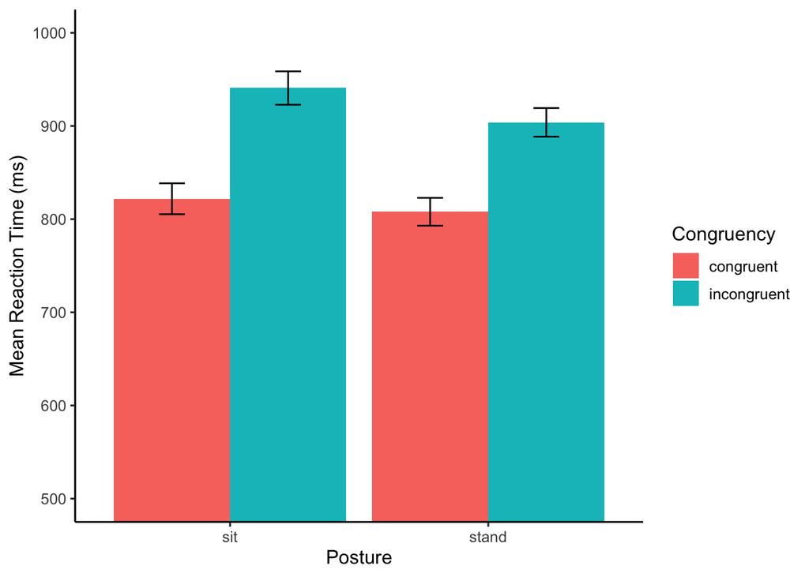

```r
library(tidyr)

# convert to long

stroop_df <- all_data %>%
  pivot_longer(cols = 1:4,
               names_to = c("Congruency","Posture"),
               names_sep = "_",
               values_to = "RTs")

# get means

overall_means <- stroop_df %>%
                  group_by(Posture,Congruency) %>%
                  summarise(meanRT = mean(RTs),
                            SEMRT = (sd(RTs)/sqrt(length(RTs))))

# plot

ggplot(overall_means, aes(x=Posture,
                          y=meanRT,
                          group=Congruency,
                          fill=Congruency))+
  geom_bar(stat="identity",position="dodge")+
  theme_classic(base_size=12)+
  ylab("Mean Reaction Time (ms)")+
  geom_errorbar(aes(ymin=meanRT-SEMRT,
                    ymax=meanRT+SEMRT),
                position=position_dodge(width=0.9),
                width=.2,
                color="black")+
  coord_cartesian(ylim=c(500,1000))
```

## power curve

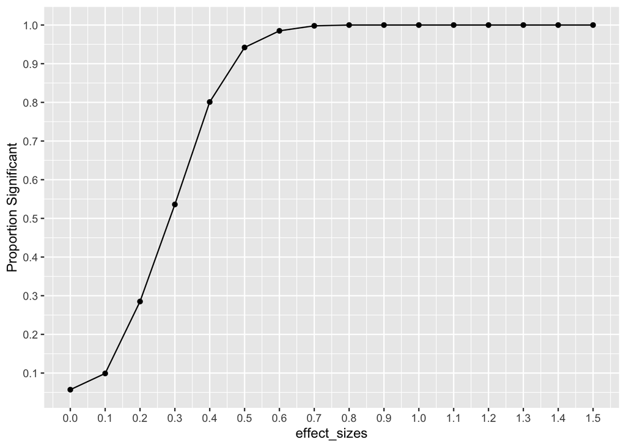

```r
effect_sizes <- seq(0,1.5,.1)
prop_significant <-c()

for(i in 1:length(effect_sizes)){
  sim_ps <- replicate(1000, t.test(replicate(50, rnorm(1, effect_sizes[i], 1)),
                                   mu = 0)$p.value)

  prop_significant[i] <- length(sim_ps[sim_ps < .05])/1000
}

plot_df <- data.frame(effect_sizes,
                      prop_significant)

ggplot(plot_df, aes(x=effect_sizes,y=prop_significant))+
  geom_line() +
  geom_point() +
  scale_x_continuous(breaks=seq(0,1.5,.1))+
  scale_y_continuous(breaks=seq(0,1,.1)) +
  ylab("Proportion Significant")
```